# Eco2Urb data

```r
setwd("/Users/Ty/Dropbox/Dendritic connectivity/SUS2020/data/Eco2Urb")
```

```
The working directory was changed to /Users/Ty/Dropbox/Dendritic connectivity/SUS2020/data/Eco2Urb inside a notebook chunk. The working directory will be reset when the chunk is finished running. Use the knitr root.dir option in the setup chunk to change the working directory for notebook chunks.
```

```r
library(sf)
library(ggplot2)
library(raster)
library(tiff)
```

```r
list.files()
```

```
 [1] "Biodiversity_module.R"       "CanALE_module.R"             "dropoutPanelSus.R"           "Eco2Urb_Data_processing.Rmd"
 [5] "languageSwitchSus.R"         "Mode_shift_module.R"         "Pedestrian_realm.R"          "rightPanelSus.R"
 [9] "scrollingTimelingSus.R"      "speciesOccDataSus.R"         "titletextSus.R"              "translation_functions.R"
[13] "zoomMenuItemSus.R"           "zoomMenuSus.R"
```

```r
setwd("/Users/Ty/Dropbox/Dendritic connectivity/SUS2020/data/Eco2Urb/DSF2FinalRasters")
```

[output not shown]

```r
list.files()
```

```
 [1] "Fig11a.asc"          "Fig11a.asc.aux.xml"  "Fig11a.asc.ovr"      "Fig11b.asc"          "Fig11b.asc.aux.xml"  "Fig11b.asc.ovr"
 [7] "Fig11c.asc"          "Fig11c.asc.aux.xml"  "Fig11c.asc.ovr"      "Fig13.tif"           "Fig13.tif.aux.xml"   "Fig13.tif.ovr"
[13] "Fig14.asc"           "Fig14.asc.aux.xml"   "Fig14.asc.ovr"       "Fig14.tif"           "Fig15.tif"           "Fig15.tif.aux.xml"
[19] "Fig15.tif.ovr"       "Fig16.tif"           "Flood_CMM.tif"       "Flood_CMM.tif.zip"   "heatcoolislands"     "heatcoolislands.zip"
```

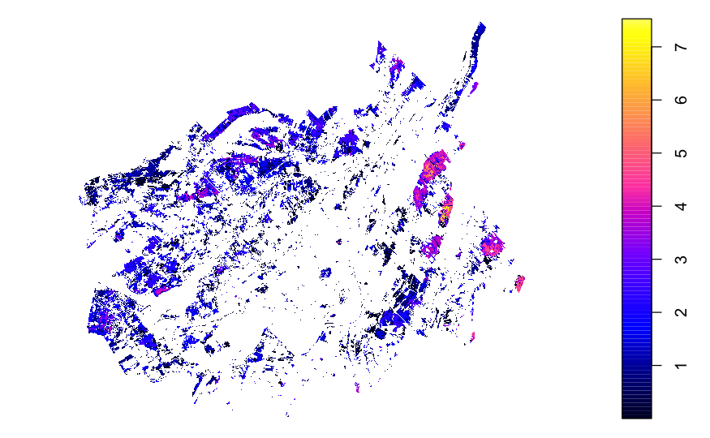

```r
tiff_11A <- read.asciigrid("/Users/Ty/Dropbox/Dendritic connectivity/SUS2020/data/Eco2Urb/DSF2FinalRasters/Fig11a.asc")

plot(tiff_11A)
```

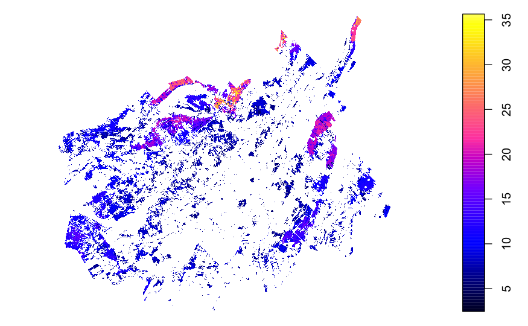

```r
tiff_11B <- read.asciigrid("/Users/Ty/Dropbox/Dendritic connectivity/SUS2020/data/Eco2Urb/DSF2FinalRasters/Fig11b.asc")

plot(tiff_11B)
```

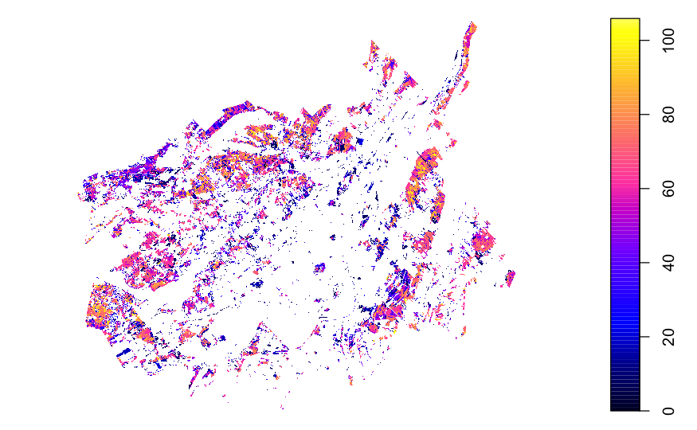

```r
tiff_11C <- read.asciigrid("/Users/Ty/Dropbox/Dendritic connectivity/SUS2020/data/Eco2Urb/DSF2FinalRasters/Fig11c.asc")

plot(tiff_11C)
```

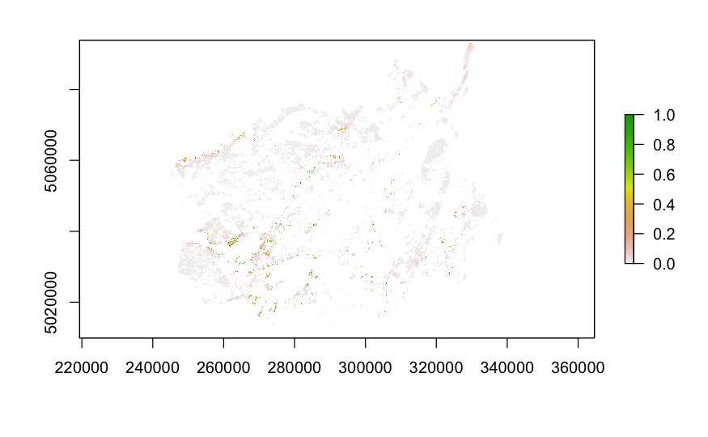

```r
tiff_13 <- raster("/Users/Ty/Dropbox/Dendritic connectivity/SUS2020/data/Eco2Urb/DSF2FinalRasters/Fig13.tif")

plot(tiff_13)
```

```r
tiff_14 <- raster("/Users/Ty/Dropbox/Dendritic connectivity/SUS2020/data/Eco2Urb/DSF2FinalRasters/Fig14.tif")
```

```
Discarded datum NAD83_Canadian_Spatial_Reference_System in CRS definition: +proj=tmerc +lat_0=0 +lon_0=-73.5 +k=0.9999 +x_0=304800 +y_0=0 +ellps=GRS80 +units=m +no_defsDiscarded datum Unknown based on GRS80 ellipsoid in CRS definition
```

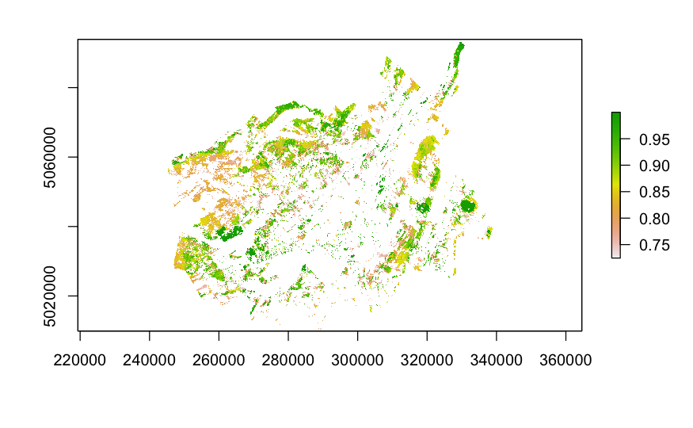

```r
plot(tiff_14)
```

```r
tiff_15 <- raster("/Users/Ty/Dropbox/Dendritic connectivity/SUS2020/data/Eco2Urb/DSF2FinalRasters/Fig15.tif")
```

```
Discarded datum unknown in CRS definition: +proj=tmerc +lat_0=0 +lon_0=-73.5 +k=0.9999 +x_0=304800 +y_0=0 +ellps=GRS80 +towgs84=0,0,0,0,0,0,0 +units=m +no_defs,
 but +towgs84= values preservedDiscarded datum Unknown based on GRS80 ellipsoid in CRS definition
```

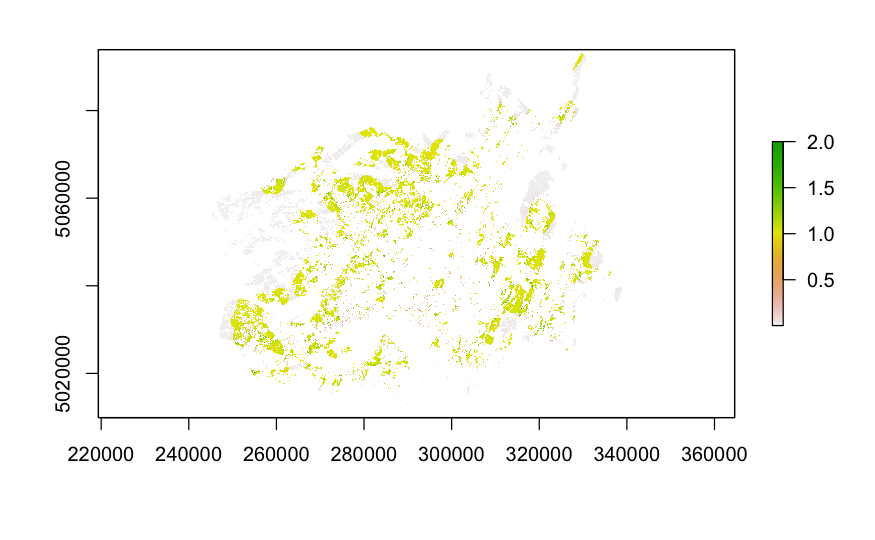

```r
plot(tiff_15)
```

[figure not shown]

```r
tiff_16 <- raster("/Users/Ty/Dropbox/Dendritic connectivity/SUS2020/data/Eco2Urb/DSF2FinalRasters/Fig16.tif")

plot(tiff_16)
```

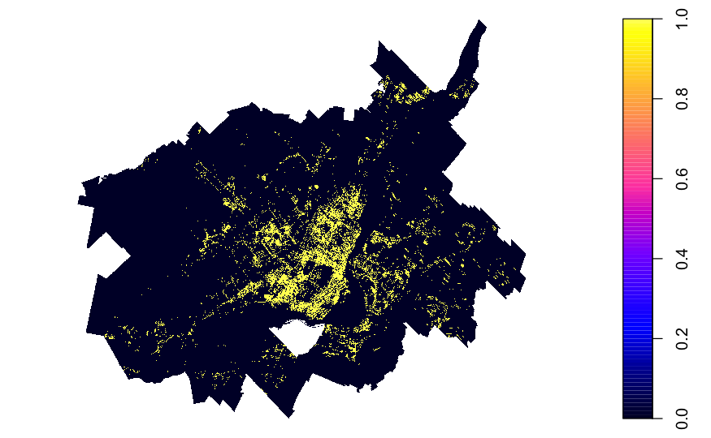

```r
heat_islands <- read.asciigrid("/Users/Ty/Dropbox/Dendritic connectivity/SUS2020/data/Eco2Urb/DSF2FinalRasters/heatcoolislands/heatislands3.asc")
cool_islands <- read.asciigrid("/Users/Ty/Dropbox/Dendritic connectivity/SUS2020/data/Eco2Urb/DSF2FinalRasters/heatcoolislands/coolislands5.asc")

plot(heat_islands)
```

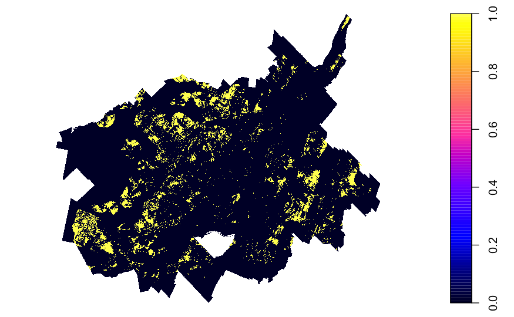

```r
plot(cool_islands)
```

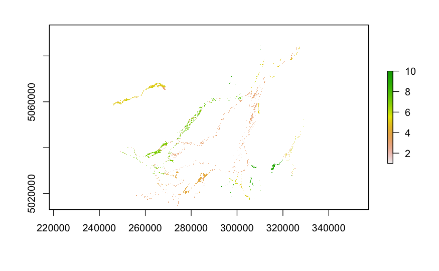

```r
flood <- raster("/Users/Ty/Dropbox/Dendritic connectivity/SUS2020/data/Eco2Urb/DSF2FinalRasters/Flood_CMM.tif/Flood_CMM.tif")
plot(flood)
```

```r
montreal_ES <- st_read("montreal-agglomeration-muni-100028-div-vf1-20201125.shp")
```

```
Error: Cannot open "montreal-agglomeration-muni-100028-div-vf1-20201125.shp"; The file doesn't seem to exist.
```

[figure not shown]

```r
montreal_ES
```

[output not shown]

“SP_ID” [integer] = shape ID “nom_arr” [character] = name of area described by shape “can_area” [number] = ? what is can? “muni_area” [integer] = why is this an integer? “perc_co” [number] = ? “sp” [integer] = number of species observed in shape area? Is this a model or data? “rrar” [number] = ? “abun” [integer] = abundance of something? “trunof” [number] = ? “stand_run” [number]= something about water runoff? “polrem” [number]= polution remediation? “stand_pol” [number]= standing polution? “carbon” [number] = what about carbon? “stand_car” [number] = why is this a decimal if the unit is a car? is this number of cars that park in a shape? “Sequestrat”[number] = sequestering rats? “stand_seq” [number] = standing sequestration of something. “Evap” [number] = evaporation from trees? “stand_evap” [number]= standing evaporation? evaporation from standing vegetation? meaning seasonal? “mtl” [factor] = in MTL city limits or data provided by MTL? or other? “order” [factor] = ? “cancarbon2” [number]= what is special about the ‘can’ designation? Are the data from canadian federal sources? “canrunoffa”[number]= “canseq2” [number] = “canpoll” [number] = what is poll?